# Lab 4 Key

```r
needs(tidyverse, rio, here, knitr, kableExtra, misty, janitor, rstatix, psych, misty)
```

## Lab 4

In an experiment, fifth grade students are individually and randomly assigned to be introduced to a set of vocabulary words by watching a lecture in one of three subject areas: physical science, social science, and history. The lecture was delivered to each child in one of two methods: traditional lecture or computer-augmented lecture. Six children experienced each combination of conditions. A vocabulary test with 60 words follows each lecture as a measure of learning.

Our research questions are:  
1. “To what extent do lecture topic and method influence the vocabulary learning of fifth grade students?”  
2. “To what extent does the effect of lecture topic on the vocabulary learning of fifth grade students depend on lecture method?”

### Notes and Background

This is a 2-factor between subjects ANOVA, with lecture topic (physical science, social science, or history) and lecture delivery method (traditional lecture or computer-augmented lecture) as the two independent variables and vocabulary learning, determined by the score on the vocabulary test, as the dependent variable. The study is intended to represent the population of fifth graders subject to these conditions.

### Data Exploration

```r
vocab4_data <- misty::read.sav(here("assignments_data", "Lab4_Vocab.sav"), use.value.labels = TRUE)

vocab4_data %>%
  group_by(inst, meth) %>%
  summarise(n = n()) %>% #new column "n" = row count of each factor grouping
  spread(meth, n)
```

```
## # A tibble: 3 × 3
## # Groups:   inst [3]
##   inst             computer standard
##   <fct>               <int>    <int>
## 1 physical science        6        6
## 2 social science          6        6
## 3 history                 6        6
```

```r
## Check Descriptives
describe(vocab4_data)
```

```
##       vars  n mean    sd median trimmed   mad min max range  skew kurtosis   se
## idnum    1 36 18.5 10.54   18.5    18.5 13.34   1  36    35  0.00    -1.30 1.76
## vocab    2 36 33.5 12.87   35.5    34.2 12.60   6  53    47 -0.54    -0.87 2.14
## inst*    3 36  2.0  0.83    2.0     2.0  1.48   1   3     2  0.00    -1.58 0.14
## meth*    4 36  1.5  0.51    1.5     1.5  0.74   1   2     1  0.00    -2.05 0.08
```

Average vocabulary score is 33.5 (SD = 12.87) and is approximately normally distributed (skew and kurtosis < ±2).

```r
#Output for each level
describeBy(x = vocab4_data$vocab, group = vocab4_data$inst,
             mat = TRUE, data = vocab4_data)
```

```
##     item           group1 vars  n mean        sd median trimmed     mad min max
## X11    1 physical science    1 12 40.0 10.795622   43.0    40.9 11.8608  18  53
## X12    2   social science    1 12 26.0 15.201675   24.5    25.9 20.7564   6  47
## X13    3          history    1 12 34.5  8.393721   35.5    34.8  8.1543  20  46
##     range        skew  kurtosis       se
## X11    35 -0.56390947 -1.003818 3.116428
## X12    41  0.03928301 -1.914109 4.388345
## X13    26 -0.36694097 -1.132315 2.423058
```

Average vocabulary score for physical science lecture is 40 words (SD = 10.80), social science is 26 words (SD = 15.20), and history is 34.5 words (SD = 8.39). Each are approximately normally distributed, with skewness and kurtosis < ±2.

Separate Boxplots

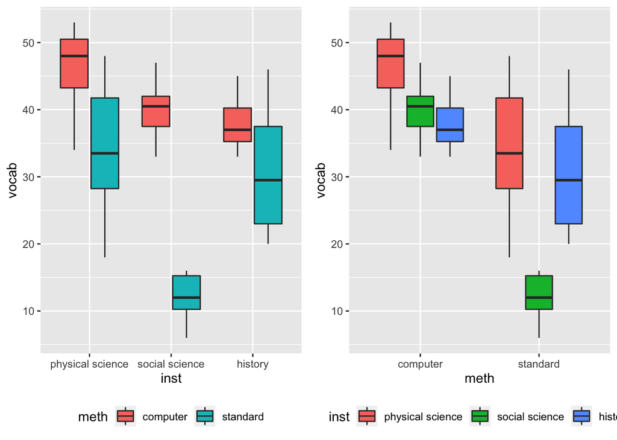

```r
library(ggplot2)
?ggplot

inst_plot <- vocab4_data %>%
  ggplot(aes(inst, vocab, fill = meth)) +
  geom_boxplot() +
  theme(legend.position="bottom")

meth_plot <- vocab4_data %>%
  ggplot(aes(meth, vocab, fill = inst)) +
  geom_boxplot() +
  theme(legend.position="bottom")

gridExtra::grid.arrange(inst_plot, meth_plot, nrow = 1)
```

```r
# checking values, for my own curiosity
vocab4_data %>%
  filter(meth == "computer") %>%
  group_by(inst) %>%
  summarise(mean = mean(vocab))
```

```
## # A tibble: 3 × 2
##   inst              mean
##   <fct>            <dbl>
## 1 physical science    46
## 2 social science      40
## 3 history             38
```

Initial interpretations from boxplots: Overall, students who attended the computer-augmented lecture scored higher on the vocabulary test than those who attended the traditional lecture. In each case, those with physical science appeared to score higher than the rest. Those attending the standard social science lecture scored the lowest.

### Checking assumptions

```r
car::leveneTest(vocab ~ inst*meth, data = vocab4_data, center = "mean")
```

```
## Levene's Test for Homogeneity of Variance (center = "mean")
##       Df F value  Pr(>F)
## group  5  2.0579 0.09877 .
##       30
## ---
## Signif. codes:  0 '***' 0.001 '**' 0.01 '*' 0.05 '.' 0.1 ' ' 1
```

For vocab, the M = 33.5, SD = 12.87, and skew and kurtosis < ±2, assuming normality, as stated before.

Observations can be assumed to be independent since participants only attended one lecture, and there is no reason to believe they may have affected another group.

### Two-way ANOVA

```r
anova_test(vocab4_data, formula = vocab ~ inst + meth + inst:meth,
                 detailed = TRUE, type = 3, effect.size = "pes")
```

```
## Coefficient covariances computed by hccm()
```

```
## ANOVA Table (type III tests)
##
##        Effect   SSn  SSd DFn DFd       F        p p<.05   pes
## 1 (Intercept) 40401 1668   1  30 726.637 1.39e-22     * 0.960
## 2        inst  1194 1668   2  30  10.737 3.04e-04     * 0.417
## 3        meth  2209 1668   1  30  39.730 5.99e-07     * 0.570
## 4   inst:meth   722 1668   2  30   6.493 5.00e-03     * 0.302
```

The effect of instructional topic, method, and the interaction of topic and method are all significant at an alpha of 0.05. Type 3 test is used and simple effects are examined below.

#### Effect sizes with omega

Let’s calculate effect size with Omega. Partial eta squared is already given in the ANOVA output.

```r
needs(MOTE)
omega.F(dfm = 2, dfe = 30,
      Fvalue = 6.493, n = 36, a = .05)
```

```
## $omega
## [1] 0.2338143
##
## $omegalow
## [1] 0.006073986
##
## $omegahigh
## [1] 0.4746705
##
## $dfm
## [1] 2
##
## $dfe
## [1] 30
##
## $F
## [1] 6.493
##
## $p
## [1] 0.00453851
##
## $estimate
## [1] "$\\omega^2$ = 0.23, 95\\% CI [0.01, 0.47]"
##
## $statistic
## [1] "$F$(2, 30) = 6.49, $p$ = .005"
```

#### Simple effects

```r
rstatix::tukey_hsd(vocab4_data, vocab ~ inst*meth) #main and simple effects (when one method/instr is held constant)
```

```
## # A tibble: 19 × 9
##    term      group1        group2 null.value estimate conf.low conf.high   p.adj
##  * <chr>     <chr>         <chr>       <dbl>    <dbl>    <dbl>     <dbl>   <dbl>
##  1 inst      physical sci… socia…          0   -14.0   -21.5       -6.50 2.08e-4
##  2 inst      physical sci… histo…          0    -5.50  -13.0        2.00 1.85e-1
##  3 inst      social scien… histo…          0     8.5     0.995     16.0  2.38e-2
##  4 meth      computer      stand…          0   -15.7   -20.7      -10.6  5.99e-7
##  5 inst:meth physical sci… socia…          0    -6.00  -19.1        7.09 7.3 e-1
##  6 inst:meth physical sci… histo…          0    -8.00  -21.1        5.09 4.46e-1
##  7 inst:meth physical sci… physi…          0   -12.0   -25.1        1.09 8.74e-2
##  8 inst:meth physical sci… socia…          0   -34.0   -47.1      -20.9  1.17e-7
##  9 inst:meth physical sci… histo…          0   -15.0   -28.1       -1.91 1.75e-2
## 10 inst:meth social scien… histo…          0    -2     -15.1       11.1  9.97e-1
## 11 inst:meth social scien… physi…          0    -6     -19.1        7.09 7.3 e-1
## 12 inst:meth social scien… socia…          0   -28     -41.1      -14.9  4.84e-6
## 13 inst:meth social scien… histo…          0    -9.00  -22.1        4.09 3.19e-1
## 14 inst:meth history:comp… physi…          0    -4     -17.1        9.09 9.36e-1
## 15 inst:meth history:comp… socia…          0   -26     -39.1      -12.9  1.74e-5
## 16 inst:meth history:comp… histo…          0    -7.00  -20.1        6.09 5.89e-1
## 17 inst:meth physical sci… socia…          0   -22     -35.1       -8.91 2.29e-4
## 18 inst:meth physical sci… histo…          0    -3.00  -16.1       10.1  9.81e-1
## 19 inst:meth social scien… histo…          0    19       5.91      32.1  1.55e-3
## # … with 1 more variable: p.adj.signif <chr>
```

```r
#don't look at effects like row 14, where both factors are changed

# Group 2 - Group 1 = estimate
```

The following differences are significant:

- physical science vs social science
- social science vs history
- computer vs standard
- social science computer vs standard
- standard physical science vs social science
- standard social science vs history

#### Marginal Means

It is good to know how to get the means here, but you can can use those values here as supplementary to the Tukey test above.

```r
means <- vocab4_data %>%
  group_by(meth) %>%
 emmeans_test(vocab ~ inst, p.adjust.method = "holm", detailed = TRUE)
rmarkdown::paged_table(means) #for mean differences and significance tests
```

|  | meth | term | .y. | group1 | group2 | null.value | estimate | se | df | conf.low | conf.high | statistic | p | p.adj | p.adj.signif |
| --- | --- | --- | --- | --- | --- | --- | --- | --- | --- | --- | --- | --- | --- | --- | --- |
| 1 | computer | inst | vocab | physical science | social science | 0 | 6 | 4.305036 | 30 | -2.7920561 | 14.79206 | 1.3937166 | 1.736427e-01 | 3.472853e-01 | ns |
| 2 | computer | inst | vocab | physical science | history | 0 | 8 | 4.305036 | 30 | -0.7920561 | 16.79206 | 1.8582888 | 7.296550e-02 | 2.188965e-01 | ns |
| 3 | computer | inst | vocab | social science | history | 0 | 2 | 4.305036 | 30 | -6.7920561 | 10.79206 | 0.4645722 | 6.455920e-01 | 6.455920e-01 | ns |
| 4 | standard | inst | vocab | physical science | social science | 0 | 22 | 4.305036 | 30 | 13.2079439 | 30.79206 | 5.1102943 | 1.706157e-05 | 5.118471e-05 | **** |
| 5 | standard | inst | vocab | physical science | history | 0 | 3 | 4.305036 | 30 | -5.7920561 | 11.79206 | 0.6968583 | 4.912565e-01 | 4.912565e-01 | ns |
| 6 | standard | inst | vocab | social science | history | 0 | -19 | 4.305036 | 30 | -27.7920561 | -10.20794 | -4.4134360 | 1.212903e-04 | 2.425807e-04 | *** |

```r
#To get actual marginal means
rmarkdown::paged_table(
  get_emmeans(means)
)
```

| meth | inst | emmean | se | df | conf.low | conf.high | method |
| --- | --- | --- | --- | --- | --- | --- | --- |
| computer | physical science | 46 | 3.04412 | 30 | 39.783078 | 52.21692 | Emmeans test |
| computer | social science | 40 | 3.04412 | 30 | 33.783078 | 46.21692 | Emmeans test |
| computer | history | 38 | 3.04412 | 30 | 31.783078 | 44.21692 | Emmeans test |
| standard | physical science | 34 | 3.04412 | 30 | 27.783078 | 40.21692 | Emmeans test |
| standard | social science | 12 | 3.04412 | 30 | 5.783078 | 18.21692 | Emmeans test |
| standard | history | 31 | 3.04412 | 30 | 24.783078 | 37.21692 | Emmeans test |

For example, from the table above we know the actual differences from Tukey test above. * social science computer vs standard = 40 vs 12 words * standard physical science vs social science = 34 vs 12 words * standard social science vs history = 12 vs 31 words

#### Univariate Comparisons

```r
model <- lm(vocab ~ inst + meth + inst:meth, data = vocab4_data)

vocab4_data %>%
  group_by(inst) %>%
  anova_test(vocab ~ meth, error = model)
```

```
## Coefficient covariances computed by hccm()
## Coefficient covariances computed by hccm()
## Coefficient covariances computed by hccm()
```

```
## # A tibble: 3 × 8
##   inst             Effect   DFn   DFd     F           p `p<.05`   ges
## * <fct>            <chr>  <dbl> <dbl> <dbl>       <dbl> <chr>   <dbl>
## 1 physical science meth       1    30  7.77 0.009       "*"     0.206
## 2 social science   meth       1    30 42.3  0.000000344 "*"     0.585
## 3 history          meth       1    30  2.64 0.114       ""      0.081
```

```r
vocab4_data %>%
  group_by(meth) %>%
  anova_test(vocab ~ inst, error = model)
```

```
## Coefficient covariances computed by hccm()
## Coefficient covariances computed by hccm()
```

```
## # A tibble: 2 × 8
##   meth     Effect   DFn   DFd     F         p `p<.05`   ges
## * <fct>    <chr>  <dbl> <dbl> <dbl>     <dbl> <chr>   <dbl>
## 1 computer inst       2    30  1.87 0.172     ""      0.111
## 2 standard inst       2    30 15.4  0.0000255 "*"     0.506
```

#### Interaction Plots

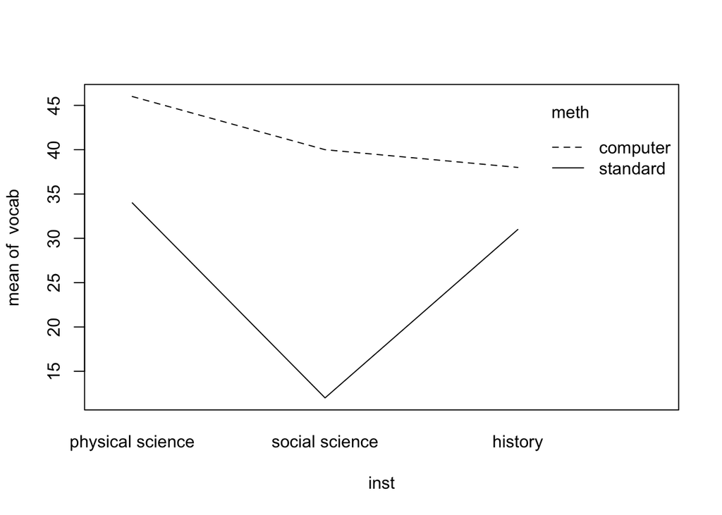

```r
with(vocab4_data, {
interaction.plot(x.factor = inst,
                 trace.factor = meth,
                 response = vocab,
                 type = "l")
})
```

Computer-augmented lectures produce consistently higher vocabulary test means than standard lectures, regardless of subject area. Meanwhile, physical science produces higher vocabulary test scores than the other two subjects, but the vocabulary test scores for social science or history depends on the lecture delivery method.

### Lab 4 APA Results

Follow-up (i.e., post-hoc) simple effects were examined with a Tukey’s HSD correction to interpret the interaction further, and found six statistically significant effects (*p* < .05). Specifically, when a lecture was delivered traditionally, students learned 22 more words on average in the physical science condition (*M* = 34) than the social science condition (*M* = 12), and a mean of 19 more words in the history condition (*M* = 31) than the social science condition (*M* = 12). In addition, in social science, students learned 28 more words on average if the lecture was computer-assisted (*M* = 40) as opposed to traditional lecture (*M* = 12).